# Risk Factor Analysis

## Outcome Variable

**Outcome Variable:** stunted

## Predictor Variables

**Intervention Variable:** predfeed36

**Adjustment Set:**

- arm
- sex
- month
- brthmon
- W_mage
- meducyrs
- feducyrs
- hhwealth_quart
- hfoodsec
- W_mhtcm
- vagbrth
- W_gagebrth
- W_birthwt
- W_birthlen
- W_nrooms
- W_nchldlt5
- W_parity
- impfloor
- impsan
- safeh20
- delta_W_mage
- delta_meducyrs
- delta_feducyrs
- delta_hhwealth_quart
- delta_hfoodsec
- delta_W_mhtcm
- delta_vagbrth
- delta_W_gagebrth
- delta_W_birthwt
- delta_W_birthlen
- delta_W_nrooms
- delta_W_nchldlt5
- delta_W_parity
- delta_impfloor
- delta_impsan
- delta_safeh20

## Stratifying Variables

The analysis was stratified on these variable(s):

- agecat
- studyid
- country

## Data Summary

| agecat | studyid | country | predfeed36 | stunted | n_cell | n |
| --- | --- | --- | --- | --- | --- | --- |
| Birth | ki0047075b-MAL-ED | BANGLADESH | 0 | 0 | 95 | 243 |
| Birth | ki0047075b-MAL-ED | BANGLADESH | 0 | 1 | 23 | 243 |
| Birth | ki0047075b-MAL-ED | BANGLADESH | 1 | 0 | 107 | 243 |
| Birth | ki0047075b-MAL-ED | BANGLADESH | 1 | 1 | 18 | 243 |
| Birth | ki0047075b-MAL-ED | BRAZIL | 0 | 0 | 141 | 185 |
| Birth | ki0047075b-MAL-ED | BRAZIL | 0 | 1 | 15 | 185 |
| Birth | ki0047075b-MAL-ED | BRAZIL | 1 | 0 | 25 | 185 |
| Birth | ki0047075b-MAL-ED | BRAZIL | 1 | 1 | 4 | 185 |
| Birth | ki0047075b-MAL-ED | INDIA | 0 | 0 | 155 | 198 |
| Birth | ki0047075b-MAL-ED | INDIA | 0 | 1 | 27 | 198 |
| Birth | ki0047075b-MAL-ED | INDIA | 1 | 0 | 11 | 198 |
| Birth | ki0047075b-MAL-ED | INDIA | 1 | 1 | 5 | 198 |
| Birth | ki0047075b-MAL-ED | NEPAL | 0 | 0 | 130 | 172 |
| Birth | ki0047075b-MAL-ED | NEPAL | 0 | 1 | 16 | 172 |
| Birth | ki0047075b-MAL-ED | NEPAL | 1 | 0 | 24 | 172 |
| Birth | ki0047075b-MAL-ED | NEPAL | 1 | 1 | 2 | 172 |
| Birth | ki0047075b-MAL-ED | PERU | 0 | 0 | 135 | 273 |
| Birth | ki0047075b-MAL-ED | PERU | 0 | 1 | 20 | 273 |
| Birth | ki0047075b-MAL-ED | PERU | 1 | 0 | 106 | 273 |
| Birth | ki0047075b-MAL-ED | PERU | 1 | 1 | 12 | 273 |
| Birth | ki0047075b-MAL-ED | SOUTH AFRICA | 0 | 0 | 211 | 236 |
| Birth | ki0047075b-MAL-ED | SOUTH AFRICA | 0 | 1 | 22 | 236 |
| Birth | ki0047075b-MAL-ED | SOUTH AFRICA | 1 | 0 | 1 | 236 |
| Birth | ki0047075b-MAL-ED | SOUTH AFRICA | 1 | 1 | 2 | 236 |
| Birth | ki0047075b-MAL-ED | TANZANIA, UNITED REPUBLIC OF | 0 | 0 | 102 | 121 |
| Birth | ki0047075b-MAL-ED | TANZANIA, UNITED REPUBLIC OF | 0 | 1 | 18 | 121 |
| Birth | ki0047075b-MAL-ED | TANZANIA, UNITED REPUBLIC OF | 1 | 0 | 1 | 121 |
| Birth | ki0047075b-MAL-ED | TANZANIA, UNITED REPUBLIC OF | 1 | 1 | 0 | 121 |
| Birth | ki1000109-EE | PAKISTAN | 0 | 0 | 0 | 4 |
| Birth | ki1000109-EE | PAKISTAN | 0 | 1 | 2 | 4 |

[output cut: 106 more lines]

The following strata were considered:

- agecat: 24 months, studyid: ki0047075b-MAL-ED, country: BANGLADESH
- agecat: 24 months, studyid: ki0047075b-MAL-ED, country: BRAZIL
- agecat: 24 months, studyid: ki0047075b-MAL-ED, country: INDIA
- agecat: 24 months, studyid: ki0047075b-MAL-ED, country: NEPAL
- agecat: 24 months, studyid: ki0047075b-MAL-ED, country: PERU
- agecat: 24 months, studyid: ki0047075b-MAL-ED, country: SOUTH AFRICA
- agecat: 24 months, studyid: ki0047075b-MAL-ED, country: TANZANIA, UNITED REPUBLIC OF
- agecat: 24 months, studyid: ki1113344-GMS-Nepal, country: NEPAL
- agecat: 24 months, studyid: ki1148112-LCNI-5, country: MALAWI
- agecat: 24 months, studyid: kiGH5241-JiVitA-3, country: BANGLADESH
- agecat: 24 months, studyid: kiGH5241-JiVitA-4, country: BANGLADESH
- agecat: 6 months, studyid: ki0047075b-MAL-ED, country: BANGLADESH
- agecat: 6 months, studyid: ki0047075b-MAL-ED, country: BRAZIL
- agecat: 6 months, studyid: ki0047075b-MAL-ED, country: INDIA
- agecat: 6 months, studyid: ki0047075b-MAL-ED, country: NEPAL
- agecat: 6 months, studyid: ki0047075b-MAL-ED, country: PERU
- agecat: 6 months, studyid: ki0047075b-MAL-ED, country: SOUTH AFRICA
- agecat: 6 months, studyid: ki0047075b-MAL-ED, country: TANZANIA, UNITED REPUBLIC OF
- agecat: 6 months, studyid: ki1000109-EE, country: PAKISTAN
- agecat: 6 months, studyid: ki1000304b-SAS-FoodSuppl, country: INDIA
- agecat: 6 months, studyid: ki1113344-GMS-Nepal, country: NEPAL
- agecat: 6 months, studyid: ki1148112-LCNI-5, country: MALAWI
- agecat: 6 months, studyid: kiGH5241-JiVitA-3, country: BANGLADESH
- agecat: 6 months, studyid: kiGH5241-JiVitA-4, country: BANGLADESH
- agecat: Birth, studyid: ki0047075b-MAL-ED, country: BANGLADESH
- agecat: Birth, studyid: ki0047075b-MAL-ED, country: BRAZIL
- agecat: Birth, studyid: ki0047075b-MAL-ED, country: INDIA
- agecat: Birth, studyid: ki0047075b-MAL-ED, country: NEPAL
- agecat: Birth, studyid: ki0047075b-MAL-ED, country: PERU
- agecat: Birth, studyid: ki0047075b-MAL-ED, country: SOUTH AFRICA
- agecat: Birth, studyid: ki0047075b-MAL-ED, country: TANZANIA, UNITED REPUBLIC OF
- agecat: Birth, studyid: ki1000109-EE, country: PAKISTAN
- agecat: Birth, studyid: kiGH5241-JiVitA-3, country: BANGLADESH
- agecat: Birth, studyid: kiGH5241-JiVitA-4, country: BANGLADESH

### Dropped Strata

Some strata were dropped due to rare outcomes:

- agecat: Birth, studyid: ki0047075b-MAL-ED, country: BRAZIL
- agecat: Birth, studyid: ki0047075b-MAL-ED, country: NEPAL
- agecat: Birth, studyid: ki0047075b-MAL-ED, country: SOUTH AFRICA
- agecat: Birth, studyid: ki0047075b-MAL-ED, country: TANZANIA, UNITED REPUBLIC OF
- agecat: Birth, studyid: ki1000109-EE, country: PAKISTAN
- agecat: 6 months, studyid: ki0047075b-MAL-ED, country: BRAZIL
- agecat: 6 months, studyid: ki0047075b-MAL-ED, country: NEPAL
- agecat: 6 months, studyid: ki0047075b-MAL-ED, country: SOUTH AFRICA
- agecat: 6 months, studyid: ki0047075b-MAL-ED, country: TANZANIA, UNITED REPUBLIC OF
- agecat: 6 months, studyid: ki1000304b-SAS-FoodSuppl, country: INDIA
- agecat: 24 months, studyid: ki0047075b-MAL-ED, country: BRAZIL
- agecat: 24 months, studyid: ki0047075b-MAL-ED, country: SOUTH AFRICA
- agecat: 24 months, studyid: ki0047075b-MAL-ED, country: TANZANIA, UNITED REPUBLIC OF

## Methods Detail

We’re interested in the causal parameters $E[Y_a]$ for all values of $a \in \mathcal{A}$. These parameters represent the mean outcome if, possibly contrary to fact, we intervened to set all units to have $A=a$. Under the randomization and positivity assumptions, these are identified by the statistical parameters $\psi_a=E_W[E_{Y|A,W}(Y|A=a,W)]$. In addition, we’re interested in the mean of $Y$, $E[Y]$ under no intervention (the observed mean). We will estimate these parameters by using SuperLearner to fit the relevant likelihood factors – $E_{Y|A,W}(Y|A=a,W)$ and $p(A=a|W)$, and then updating our likelihood fit using a joint TMLE.

For unadjusted analyses ($W=\{\}$), initial likelihoods were estimated using Lrnr_glm to estimate the simple $E(Y|A)$ and Lrnr_mean to estimate $p(A)$. For adjusted analyses, a small library containing Lrnr_glmnet, Lrnr_xgboost, and Lrnr_mean was used.

Having estimated these parameters, we will then use the delta method to estimate relative risks and attributable risks relative to a prespecified baseline level of $A$.

# Results Detail

## Results Plots

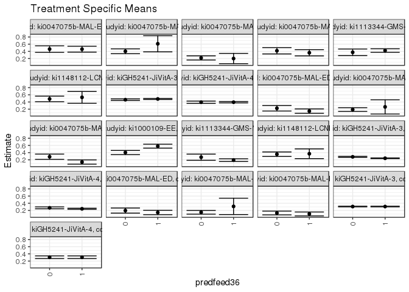

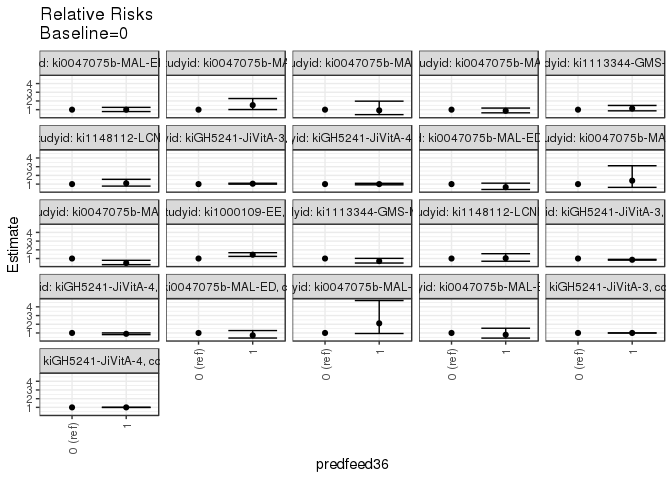

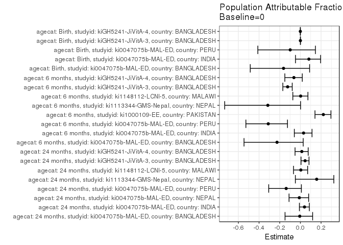

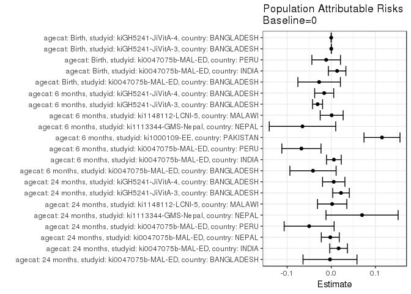

## Results Table

### Parameter: TSM

| agecat | studyid | country | intervention_level | baseline_level | estimate | ci_lower | ci_upper |
| --- | --- | --- | --- | --- | --- | --- | --- |
| Birth | ki0047075b-MAL-ED | BANGLADESH | 0 | NA | 0.1962481 | 0.1250318 | 0.2674644 |
| Birth | ki0047075b-MAL-ED | BANGLADESH | 1 | NA | 0.1430842 | 0.0816620 | 0.2045064 |
| Birth | ki0047075b-MAL-ED | INDIA | 0 | NA | 0.1483516 | 0.0965804 | 0.2001228 |
| Birth | ki0047075b-MAL-ED | INDIA | 1 | NA | 0.3125000 | 0.0848074 | 0.5401926 |
| Birth | ki0047075b-MAL-ED | PERU | 0 | NA | 0.1287548 | 0.0761917 | 0.1813179 |
| Birth | ki0047075b-MAL-ED | PERU | 1 | NA | 0.1019713 | 0.0476765 | 0.1562661 |
| Birth | kiGH5241-JiVitA-3 | BANGLADESH | 0 | NA | 0.3083832 | 0.2997138 | 0.3170527 |
| Birth | kiGH5241-JiVitA-3 | BANGLADESH | 1 | NA | 0.3083887 | 0.2997182 | 0.3170593 |
| Birth | kiGH5241-JiVitA-4 | BANGLADESH | 0 | NA | 0.3069005 | 0.2696341 | 0.3441668 |
| Birth | kiGH5241-JiVitA-4 | BANGLADESH | 1 | NA | 0.3066996 | 0.2694405 | 0.3439587 |
| 6 months | ki0047075b-MAL-ED | BANGLADESH | 0 | NA | 0.2247921 | 0.1481182 | 0.3014660 |
| 6 months | ki0047075b-MAL-ED | BANGLADESH | 1 | NA | 0.1456233 | 0.0847180 | 0.2065287 |
| 6 months | ki0047075b-MAL-ED | INDIA | 0 | NA | 0.1889401 | 0.1367451 | 0.2411351 |
| 6 months | ki0047075b-MAL-ED | INDIA | 1 | NA | 0.2631579 | 0.0647364 | 0.4615794 |
| 6 months | ki0047075b-MAL-ED | PERU | 0 | NA | 0.2853912 | 0.2120272 | 0.3587552 |
| 6 months | ki0047075b-MAL-ED | PERU | 1 | NA | 0.1379537 | 0.0785155 | 0.1973919 |
| 6 months | ki1000109-EE | PAKISTAN | 0 | NA | 0.4027036 | 0.3445837 | 0.4608235 |
| 6 months | ki1000109-EE | PAKISTAN | 1 | NA | 0.5800796 | 0.5256959 | 0.6344633 |
| 6 months | ki1113344-GMS-Nepal | NEPAL | 0 | NA | 0.2725229 | 0.1865216 | 0.3585242 |
| 6 months | ki1113344-GMS-Nepal | NEPAL | 1 | NA | 0.1913017 | 0.1538380 | 0.2287654 |
| 6 months | ki1148112-LCNI-5 | MALAWI | 0 | NA | 0.3557268 | 0.2931262 | 0.4183275 |
| 6 months | ki1148112-LCNI-5 | MALAWI | 1 | NA | 0.3684943 | 0.2330634 | 0.5039252 |
| 6 months | kiGH5241-JiVitA-3 | BANGLADESH | 0 | NA | 0.2825211 | 0.2684652 | 0.2965771 |
| 6 months | kiGH5241-JiVitA-3 | BANGLADESH | 1 | NA | 0.2423636 | 0.2333145 | 0.2514127 |
| 6 months | kiGH5241-JiVitA-4 | BANGLADESH | 0 | NA | 0.2719026 | 0.2449611 | 0.2988440 |
| 6 months | kiGH5241-JiVitA-4 | BANGLADESH | 1 | NA | 0.2450729 | 0.2293482 | 0.2607976 |
| 24 months | ki0047075b-MAL-ED | BANGLADESH | 0 | NA | 0.4626092 | 0.3716490 | 0.5535695 |
| 24 months | ki0047075b-MAL-ED | BANGLADESH | 1 | NA | 0.4604985 | 0.3787835 | 0.5422135 |
| 24 months | ki0047075b-MAL-ED | INDIA | 0 | NA | 0.4019139 | 0.3352973 | 0.4685304 |
| 24 months | ki0047075b-MAL-ED | INDIA | 1 | NA | 0.6111111 | 0.3854050 | 0.8368173 |
| 24 months | ki0047075b-MAL-ED | NEPAL | 0 | NA | 0.2171717 | 0.1596138 | 0.2747296 |
| 24 months | ki0047075b-MAL-ED | NEPAL | 1 | NA | 0.2000000 | 0.0565495 | 0.3434505 |
| 24 months | ki0047075b-MAL-ED | PERU | 0 | NA | 0.4152117 | 0.3280538 | 0.5023697 |
| 24 months | ki0047075b-MAL-ED | PERU | 1 | NA | 0.3605800 | 0.2738552 | 0.4473049 |
| 24 months | ki1113344-GMS-Nepal | NEPAL | 0 | NA | 0.3731736 | 0.2814706 | 0.4648767 |
| 24 months | ki1113344-GMS-Nepal | NEPAL | 1 | NA | 0.4221386 | 0.3722798 | 0.4719975 |
| 24 months | ki1148112-LCNI-5 | MALAWI | 0 | NA | 0.4847593 | 0.4060436 | 0.5634750 |
| 24 months | ki1148112-LCNI-5 | MALAWI | 1 | NA | 0.5294568 | 0.3655399 | 0.6933738 |
| 24 months | kiGH5241-JiVitA-3 | BANGLADESH | 0 | NA | 0.4636663 | 0.4407453 | 0.4865873 |
| 24 months | kiGH5241-JiVitA-3 | BANGLADESH | 1 | NA | 0.4838933 | 0.4688364 | 0.4989501 |
| 24 months | kiGH5241-JiVitA-4 | BANGLADESH | 0 | NA | 0.3936787 | 0.3625203 | 0.4248371 |
| 24 months | kiGH5241-JiVitA-4 | BANGLADESH | 1 | NA | 0.3936004 | 0.3738492 | 0.4133516 |

### Parameter: E(Y)

| agecat | studyid | country | intervention_level | baseline_level | estimate | ci_lower | ci_upper |
| --- | --- | --- | --- | --- | --- | --- | --- |
| Birth | ki0047075b-MAL-ED | BANGLADESH | NA | NA | 0.1687243 | 0.1215395 | 0.2159090 |
| Birth | ki0047075b-MAL-ED | INDIA | NA | NA | 0.1616162 | 0.1102143 | 0.2130180 |
| Birth | ki0047075b-MAL-ED | PERU | NA | NA | 0.1172161 | 0.0789879 | 0.1554444 |
| Birth | kiGH5241-JiVitA-3 | BANGLADESH | NA | NA | 0.3084038 | 0.2997331 | 0.3170746 |
| Birth | kiGH5241-JiVitA-4 | BANGLADESH | NA | NA | 0.3067400 | 0.2694794 | 0.3440006 |
| 6 months | ki0047075b-MAL-ED | BANGLADESH | NA | NA | 0.1833333 | 0.1342773 | 0.2323893 |
| 6 months | ki0047075b-MAL-ED | INDIA | NA | NA | 0.1949153 | 0.1442678 | 0.2455627 |
| 6 months | ki0047075b-MAL-ED | PERU | NA | NA | 0.2177122 | 0.1684866 | 0.2669378 |
| 6 months | ki1000109-EE | PAKISTAN | NA | NA | 0.5177112 | 0.4665188 | 0.5689035 |
| 6 months | ki1113344-GMS-Nepal | NEPAL | NA | NA | 0.2072243 | 0.1725535 | 0.2418951 |
| 6 months | ki1148112-LCNI-5 | MALAWI | NA | NA | 0.3566176 | 0.2995882 | 0.4136471 |
| 6 months | kiGH5241-JiVitA-3 | BANGLADESH | NA | NA | 0.2514393 | 0.2427410 | 0.2601375 |
| 6 months | kiGH5241-JiVitA-4 | BANGLADESH | NA | NA | 0.2558140 | 0.2405969 | 0.2710310 |
| 24 months | ki0047075b-MAL-ED | BANGLADESH | NA | NA | 0.4597156 | 0.3923103 | 0.5271210 |
| 24 months | ki0047075b-MAL-ED | INDIA | NA | NA | 0.4185022 | 0.3541865 | 0.4828179 |
| 24 months | ki0047075b-MAL-ED | NEPAL | NA | NA | 0.2149123 | 0.1614774 | 0.2683472 |
| 24 months | ki0047075b-MAL-ED | PERU | NA | NA | 0.3650000 | 0.2981110 | 0.4318890 |
| 24 months | ki1113344-GMS-Nepal | NEPAL | NA | NA | 0.4429825 | 0.3973399 | 0.4886250 |
| 24 months | ki1148112-LCNI-5 | MALAWI | NA | NA | 0.4867725 | 0.4153250 | 0.5582200 |
| 24 months | kiGH5241-JiVitA-3 | BANGLADESH | NA | NA | 0.4857314 | 0.4714029 | 0.5000599 |
| 24 months | kiGH5241-JiVitA-4 | BANGLADESH | NA | NA | 0.3992046 | 0.3802350 | 0.4181742 |

### Parameter: RR

| agecat | studyid | country | intervention_level | baseline_level | estimate | ci_lower | ci_upper |
| --- | --- | --- | --- | --- | --- | --- | --- |
| Birth | ki0047075b-MAL-ED | BANGLADESH | 0 | 0 | 1.0000000 | 1.0000000 | 1.0000000 |
| Birth | ki0047075b-MAL-ED | BANGLADESH | 1 | 0 | 0.7290983 | 0.4167017 | 1.2756951 |
| Birth | ki0047075b-MAL-ED | INDIA | 0 | 0 | 1.0000000 | 1.0000000 | 1.0000000 |
| Birth | ki0047075b-MAL-ED | INDIA | 1 | 0 | 2.1064815 | 0.9390763 | 4.7251373 |
| Birth | ki0047075b-MAL-ED | PERU | 0 | 0 | 1.0000000 | 1.0000000 | 1.0000000 |
| Birth | ki0047075b-MAL-ED | PERU | 1 | 0 | 0.7919808 | 0.4064872 | 1.5430586 |
| Birth | kiGH5241-JiVitA-3 | BANGLADESH | 0 | 0 | 1.0000000 | 1.0000000 | 1.0000000 |
| Birth | kiGH5241-JiVitA-3 | BANGLADESH | 1 | 0 | 1.0000179 | 0.9999627 | 1.0000731 |
| Birth | kiGH5241-JiVitA-4 | BANGLADESH | 0 | 0 | 1.0000000 | 1.0000000 | 1.0000000 |
| Birth | kiGH5241-JiVitA-4 | BANGLADESH | 1 | 0 | 0.9993456 | 0.9982279 | 1.0004645 |
| 6 months | ki0047075b-MAL-ED | BANGLADESH | 0 | 0 | 1.0000000 | 1.0000000 | 1.0000000 |
| 6 months | ki0047075b-MAL-ED | BANGLADESH | 1 | 0 | 0.6478135 | 0.3783918 | 1.1090680 |
| 6 months | ki0047075b-MAL-ED | INDIA | 0 | 0 | 1.0000000 | 1.0000000 | 1.0000000 |
| 6 months | ki0047075b-MAL-ED | INDIA | 1 | 0 | 1.3928113 | 0.6239462 | 3.1091194 |
| 6 months | ki0047075b-MAL-ED | PERU | 0 | 0 | 1.0000000 | 1.0000000 | 1.0000000 |
| 6 months | ki0047075b-MAL-ED | PERU | 1 | 0 | 0.4833846 | 0.2933516 | 0.7965208 |
| 6 months | ki1000109-EE | PAKISTAN | 0 | 0 | 1.0000000 | 1.0000000 | 1.0000000 |
| 6 months | ki1000109-EE | PAKISTAN | 1 | 0 | 1.4404628 | 1.2428488 | 1.6694976 |
| 6 months | ki1113344-GMS-Nepal | NEPAL | 0 | 0 | 1.0000000 | 1.0000000 | 1.0000000 |
| 6 months | ki1113344-GMS-Nepal | NEPAL | 1 | 0 | 0.7019656 | 0.4845012 | 1.0170370 |
| 6 months | ki1148112-LCNI-5 | MALAWI | 0 | 0 | 1.0000000 | 1.0000000 | 1.0000000 |
| 6 months | ki1148112-LCNI-5 | MALAWI | 1 | 0 | 1.0358911 | 0.6894076 | 1.5565110 |
| 6 months | kiGH5241-JiVitA-3 | BANGLADESH | 0 | 0 | 1.0000000 | 1.0000000 | 1.0000000 |
| 6 months | kiGH5241-JiVitA-3 | BANGLADESH | 1 | 0 | 0.8578600 | 0.8132775 | 0.9048864 |
| 6 months | kiGH5241-JiVitA-4 | BANGLADESH | 0 | 0 | 1.0000000 | 1.0000000 | 1.0000000 |
| 6 months | kiGH5241-JiVitA-4 | BANGLADESH | 1 | 0 | 0.9013261 | 0.8097635 | 1.0032419 |
| 24 months | ki0047075b-MAL-ED | BANGLADESH | 0 | 0 | 1.0000000 | 1.0000000 | 1.0000000 |
| 24 months | ki0047075b-MAL-ED | BANGLADESH | 1 | 0 | 0.9954373 | 0.7839436 | 1.2639881 |
| 24 months | ki0047075b-MAL-ED | INDIA | 0 | 0 | 1.0000000 | 1.0000000 | 1.0000000 |
| 24 months | ki0047075b-MAL-ED | INDIA | 1 | 0 | 1.5205026 | 1.0143184 | 2.2792925 |
| 24 months | ki0047075b-MAL-ED | NEPAL | 0 | 0 | 1.0000000 | 1.0000000 | 1.0000000 |
| 24 months | ki0047075b-MAL-ED | NEPAL | 1 | 0 | 0.9209302 | 0.4286889 | 1.9783869 |
| 24 months | ki0047075b-MAL-ED | PERU | 0 | 0 | 1.0000000 | 1.0000000 | 1.0000000 |
| 24 months | ki0047075b-MAL-ED | PERU | 1 | 0 | 0.8684245 | 0.6371421 | 1.1836624 |
| 24 months | ki1113344-GMS-Nepal | NEPAL | 0 | 0 | 1.0000000 | 1.0000000 | 1.0000000 |
| 24 months | ki1113344-GMS-Nepal | NEPAL | 1 | 0 | 1.1312124 | 0.8637268 | 1.4815349 |
| 24 months | ki1148112-LCNI-5 | MALAWI | 0 | 0 | 1.0000000 | 1.0000000 | 1.0000000 |
| 24 months | ki1148112-LCNI-5 | MALAWI | 1 | 0 | 1.0922057 | 0.7707109 | 1.5478088 |
| 24 months | kiGH5241-JiVitA-3 | BANGLADESH | 0 | 0 | 1.0000000 | 1.0000000 | 1.0000000 |
| 24 months | kiGH5241-JiVitA-3 | BANGLADESH | 1 | 0 | 1.0436239 | 0.9909053 | 1.0991473 |
| 24 months | kiGH5241-JiVitA-4 | BANGLADESH | 0 | 0 | 1.0000000 | 1.0000000 | 1.0000000 |
| 24 months | kiGH5241-JiVitA-4 | BANGLADESH | 1 | 0 | 0.9998011 | 0.9187830 | 1.0879634 |

### Parameter: PAR

| agecat | studyid | country | intervention_level | baseline_level | estimate | ci_lower | ci_upper |
| --- | --- | --- | --- | --- | --- | --- | --- |
| Birth | ki0047075b-MAL-ED | BANGLADESH | 0 | NA | -0.0275238 | -0.0757388 | 0.0206912 |
| Birth | ki0047075b-MAL-ED | INDIA | 0 | NA | 0.0132645 | -0.0066118 | 0.0331408 |
| Birth | ki0047075b-MAL-ED | PERU | 0 | NA | -0.0115387 | -0.0440197 | 0.0209424 |
| Birth | kiGH5241-JiVitA-3 | BANGLADESH | 0 | NA | 0.0000206 | 0.0000075 | 0.0000337 |
| Birth | kiGH5241-JiVitA-4 | BANGLADESH | 0 | NA | -0.0001605 | -0.0004332 | 0.0001123 |
| 6 months | ki0047075b-MAL-ED | BANGLADESH | 0 | NA | -0.0414587 | -0.0938745 | 0.0109571 |
| 6 months | ki0047075b-MAL-ED | INDIA | 0 | NA | 0.0059752 | -0.0107434 | 0.0226938 |
| 6 months | ki0047075b-MAL-ED | PERU | 0 | NA | -0.0676790 | -0.1121331 | -0.0232250 |
| 6 months | ki1000109-EE | PAKISTAN | 0 | NA | 0.1150076 | 0.0741900 | 0.1558251 |
| 6 months | ki1113344-GMS-Nepal | NEPAL | 0 | NA | -0.0652986 | -0.1406784 | 0.0100813 |
| 6 months | ki1148112-LCNI-5 | MALAWI | 0 | NA | 0.0008908 | -0.0251625 | 0.0269442 |
| 6 months | kiGH5241-JiVitA-3 | BANGLADESH | 0 | NA | -0.0310819 | -0.0424260 | -0.0197378 |
| 6 months | kiGH5241-JiVitA-4 | BANGLADESH | 0 | NA | -0.0160886 | -0.0376805 | 0.0055032 |
| 24 months | ki0047075b-MAL-ED | BANGLADESH | 0 | NA | -0.0028936 | -0.0640745 | 0.0582873 |
| 24 months | ki0047075b-MAL-ED | INDIA | 0 | NA | 0.0165883 | -0.0034748 | 0.0366514 |
| 24 months | ki0047075b-MAL-ED | NEPAL | 0 | NA | -0.0022594 | -0.0226112 | 0.0180923 |
| 24 months | ki0047075b-MAL-ED | PERU | 0 | NA | -0.0502117 | -0.1068906 | 0.0064672 |
| 24 months | ki1113344-GMS-Nepal | NEPAL | 0 | NA | 0.0698088 | -0.0119901 | 0.1516078 |
| 24 months | ki1148112-LCNI-5 | MALAWI | 0 | NA | 0.0020132 | -0.0312214 | 0.0352478 |
| 24 months | kiGH5241-JiVitA-3 | BANGLADESH | 0 | NA | 0.0220650 | 0.0032423 | 0.0408878 |
| 24 months | kiGH5241-JiVitA-4 | BANGLADESH | 0 | NA | 0.0055259 | -0.0198282 | 0.0308800 |

### Parameter: PAF

| agecat | studyid | country | intervention_level | baseline_level | estimate | ci_lower | ci_upper |
| --- | --- | --- | --- | --- | --- | --- | --- |
| Birth | ki0047075b-MAL-ED | BANGLADESH | 0 | NA | -0.1631291 | -0.4850322 | 0.0889966 |
| Birth | ki0047075b-MAL-ED | INDIA | 0 | NA | 0.0820742 | -0.0474702 | 0.1955973 |
| Birth | ki0047075b-MAL-ED | PERU | 0 | NA | -0.0984391 | -0.4119205 | 0.1454416 |
| Birth | kiGH5241-JiVitA-3 | BANGLADESH | 0 | NA | 0.0000668 | 0.0000244 | 0.0001092 |
| Birth | kiGH5241-JiVitA-4 | BANGLADESH | 0 | NA | -0.0005231 | -0.0014140 | 0.0003670 |
| 6 months | ki0047075b-MAL-ED | BANGLADESH | 0 | NA | -0.2261385 | -0.5454316 | 0.0271872 |
| 6 months | ki0047075b-MAL-ED | INDIA | 0 | NA | 0.0306552 | -0.0588132 | 0.1125636 |
| 6 months | ki0047075b-MAL-ED | PERU | 0 | NA | -0.3108646 | -0.5274696 | -0.1249757 |
| 6 months | ki1000109-EE | PAKISTAN | 0 | NA | 0.2221462 | 0.1410887 | 0.2955541 |
| 6 months | ki1113344-GMS-Nepal | NEPAL | 0 | NA | -0.3151105 | -0.7323812 | 0.0016540 |
| 6 months | ki1148112-LCNI-5 | MALAWI | 0 | NA | 0.0024980 | -0.0733001 | 0.0729431 |
| 6 months | kiGH5241-JiVitA-3 | BANGLADESH | 0 | NA | -0.1236159 | -0.1700131 | -0.0790585 |
| 6 months | kiGH5241-JiVitA-4 | BANGLADESH | 0 | NA | -0.0628919 | -0.1506548 | 0.0181771 |
| 24 months | ki0047075b-MAL-ED | BANGLADESH | 0 | NA | -0.0062943 | -0.1485854 | 0.1183692 |
| 24 months | ki0047075b-MAL-ED | INDIA | 0 | NA | 0.0396374 | -0.0096750 | 0.0865413 |
| 24 months | ki0047075b-MAL-ED | NEPAL | 0 | NA | -0.0105133 | -0.1097728 | 0.0798683 |
| 24 months | ki0047075b-MAL-ED | PERU | 0 | NA | -0.1375664 | -0.3066207 | 0.0096152 |
| 24 months | ki1113344-GMS-Nepal | NEPAL | 0 | NA | 0.1575882 | -0.0487693 | 0.3233425 |
| 24 months | ki1148112-LCNI-5 | MALAWI | 0 | NA | 0.0041358 | -0.0665356 | 0.0701244 |
| 24 months | kiGH5241-JiVitA-3 | BANGLADESH | 0 | NA | 0.0454264 | 0.0059422 | 0.0833423 |
| 24 months | kiGH5241-JiVitA-4 | BANGLADESH | 0 | NA | 0.0138423 | -0.0517394 | 0.0753346 |